# analyze TANGO result for XP_028889033 homologs

Bin He, basad on scripts written by Rachel Smoak

2020-07-26

## Goal

- Analyze TANGO predictions to extract $/beta$-aggregation prone sequences in XP_028889033 homologs.
- Attempt to cluster those sequences by amino acid sequence similarity, and explore the question of the evolution of the C-terminal portion (non Hyg_reg_CWP portion) of the protein homologs, from the perspective of the $\beta$-aggregation prone motifs.

  In other words, we are curious about whether homologs that are more closely related based on the N-terminal domain also share more similarity in their C-terminus sequences. The expectation is yes, which would support the evolutionary model where the ancestral gene was repeatedly duplicated independently in various lineages, and the duplicates subsequently went through fast evolution of their C-terminus, potentially through de novo mutations and repeat-mediated tandem duplications and losses, which led to different lengths and composition of the C-terminus. This, in turn, made the homologs show different total length and domain architecture, which either reflected species-specific requirement for the same function or evolution of distinct functions. For the former, one could imagine that for a homolog in one species to function as an adhesin, the NTD must protrude outside the cell wall matrix, and since different species have different cell wall matrix thickness and composition, the stalk of the protein must adjust itself so the NTD is raised enough to protrude outside.

## Custom function to extract information from TANGO output

This function extracts the information of interest from the TANGO output file. It is designed to be used on a single file. Looping through all files in a folder can be easily achieved with `sapply` over a list of files using `list.files`.

```r
extract_tango <- function(tango_output, agg_threshold = 5, required_in_serial = 5) {
    require(tidyverse)
    tmp <- read_tsv(file = tango_output, col_types = "icddddd") %>%
        # a boolean vector for residues above threshold
        mutate(pass = Aggregation > agg_threshold)
    pass.rle <- rle(tmp$pass) # this creates a run length encoding that will be useful for identifying the sub-sequences in a run longer than certain length
    # --- Explanation ---
    # this rle object is at the core of this function
    # an example of the rle looks like
    #   lengths: int[1:10] 5 19 20 8 1 5 19 6 181 18
    #   values: logi[1:10] F T  F  T F T F  T F   T
    #   note that by definition the values will always be T/F interdigited
    # our goal is to identify the sub-sequences that is defined as a stretch of
    # n consecutive positions with a score greater than the cutoff and record the
    # sub-sequence, its length, start and end position, 90% quantile of the score
    # --- End of explanation ---
    # 1. assigns a unique id for each run of events
    tmp$group <- rep(1:length(pass.rle$lengths), times = pass.rle$lengths)
    # 2. extract the subsequences
    agg.seq <- tmp %>%
        filter(pass) %>% # drop residues not predicted to have aggregation potential
        group_by(group) %>% # cluster by the runs
        summarize(seq = paste0(aa, collapse = ""),
                  start = min(res), end = max(res), length = n(),
                  median = median(Aggregation),
                  q90 = quantile(Aggregation, probs = 0.9),
                  ivt = sum(aa %in% c("I","V","T")) / length(aa),
                  .groups = "drop") %>%
        mutate(interval = start - lag(end) - 1) %>%
        filter(length >= required_in_serial) %>%
        select(-group)
    return(agg.seq)
}
```

## Apply to my XP_028889033 homologs

```r
getwd()
```

```
[1] "/Users/bhe2/Documents/work/current/C037-Cand-auris-adhesin/02-case-studies/output/homolog-properties/2020-07-24"
```

```r
tango.output.files <- list.files(path = "tango-output", pattern = ".txt|.txt.gz", full.names = T)
# the read_csv() function used in the custom function can automatically decompress gzipped files
tango.res <- lapply(tango.output.files, extract_tango)
names(tango.res) <- gsub(".txt|.txt.gz", "", basename(tango.output.files))
# to add species information
seqInfo <- read_tsv("XP_028889033_homologs.tsv", comment = "#", col_types = c("ccci"))
tango.res.df <- bind_rows(tango.res, .id = "id") %>%
  left_join(select(seqInfo, -length), by = c("id" = "id"))
# save the tango output
write_tsv(tango.res.df, "tango_summary_table.tsv.gz")
# mutate(species = str_split(id, "_(?!.*_)", simplify = TRUE)[,2])
# extract the species names
# credit: https://stackoverflow.com/questions/20454768/how-to-split-a-string-from-right-to-left-like-pythons-rsplit
# the split pattern is equivalent to the rsplit() function in python
```

## Exploratory data analysis of TANGO motifs

### TANGO hit sequences in and outside of PF11765 (Hyphal_reg_CWP domain)

We will group the TANGO sequences into two groups based on whether they are in within the N-terminal Hyp_reg_CWP domain or not.

```r
# include the pfam domain information to classify the tango sequences
pfam <- read_tsv("raw-output/HMMER-HMMScan-Pfam-hits.tsv", col_types = "ciiiicciiidddiic")
tango.res.df1 <- tango.res.df %>%
  left_join(pfam %>%
              filter(hmm_name == "Hyphal_reg_CWP") %>%
              select(name = seq_id, domain.start = envelope_start, domain.end = envelope_end),
            by = c("name" = "name")) %>%
  mutate(in.domain = (start >= domain.start-10 & end <= domain.end)) %>%
  select(-domain.start, -domain.end) %>%
  # there is a problem with one sequence, XP_024712318, which have two PF11765, and causes the
  # code above to generate duplicate entries for each sequence
  group_by(id,seq,start) %>% # this will collapse them again
  mutate(in.domain = any(in.domain)) %>% # this will combine the different domain checks into one
  distinct()
```

Let’s see if the motifs within the Hyphal_reg_CWP domain look different compared with those outside the domain.

```r
# find unique motifs and count the number of proteins and species represented
motif.summary <- tango.res.df1 %>%
    group_by(in.domain, seq) %>%
    summarize(n = n(), n.prot = n_distinct(id), n.sps = n_distinct(species),
              medScore = round(mean(median),1),
              IVT = round(mean(ivt),2),
              avg.intv = round(mean(interval, na.rm = T),1), sd.intv = round(sd(interval, na.rm = T),1),
              species = paste0(unique(species), collapse = ","), .groups = "drop") %>%
    arrange(desc(n))

# TANGO sequences inside the Hyphal_reg_CWP domain
print(filter(motif.summary, in.domain) %>% select(-in.domain))
```

| seq | n | n.prot | n.sps | medScore | IVT | avg.intv | sd.intv | species |
| --- | --- | --- | --- | --- | --- | --- | --- | --- |
| FQVVT | 8 | 8 | 3 | 6.1 | 0.60 | 39.8 | 19.1 | Cparapsilosis,Cdubliniensis,Calbicans |
| MIVQAV | 7 | 7 | 2 | 9.8 | 0.50 | 14.6 | 2.4 | Cdubliniensis,Calbicans |
| GLLVFY | 6 | 6 | 3 | 92.6 | 0.17 | 45.2 | 12.2 | Cparapsilosis,Sstipitis,Ctropicalis |
| LFSIVT | 6 | 6 | 3 | 40.3 | 0.50 | 48.8 | 32.6 | Sstipitis,Cdubliniensis,Calbicans |
| LLSFY | 5 | 5 | 2 | 12.7 | 0.00 | 58.0 | 0.0 | Cdubliniensis,Calbicans |
| VYYSIV | 5 | 5 | 4 | 34.3 | 0.50 | 22.2 | 1.6 | Sstipitis,Cduobushaemulonis,Chaemuloni,Cauris |
| WFVTS | 5 | 5 | 3 | 6.1 | 0.40 | 8.6 | 0.5 | Cpseudohaemulonis,Cduobushaemulonis,Chaemuloni |
| AYWSII | 4 | 4 | 2 | 21.7 | 0.33 | 20.0 | 11.4 | Cdubliniensis,Calbicans |
| FYVTS | 4 | 4 | 3 | 6.7 | 0.40 | 10.5 | 3.7 | Chaemuloni,Cauris,Dhansenii |
| GLIVAY | 4 | 4 | 2 | 62.7 | 0.33 | 17.5 | 9.0 | Cdubliniensis,Calbicans |

[output cut: 533 more lines]

```r
# TANGO sequences outside the Hyphal_reg_CWP domain
print(filter(motif.summary, !in.domain) %>% select(-in.domain))
```

| seq | n | n.prot | n.sps | medScore | IVT | avg.intv | sd.intv | species |
| --- | --- | --- | --- | --- | --- | --- | --- | --- |
| GVVIVTT | 279 | 17 | 4 | 82.9 | 0.86 | 38.3 | 25.7 | Cauris,Cpseudohaemulonis,Cduobushaemulonis,Chaemuloni |
| GVVVVTT | 50 | 8 | 4 | 84.1 | 0.86 | 30.0 | 24.1 | Cpseudohaemulonis,Cduobushaemulonis,Chaemuloni,Cauris |
| GVIIVTT | 39 | 12 | 4 | 82.1 | 0.86 | 48.7 | 40.8 | Cpseudohaemulonis,Cduobushaemulonis,Chaemuloni,Cauris |
| YTTFTTTFT | 25 | 2 | 2 | 11.5 | 0.67 | 16.8 | 2.2 | Cpseudohaemulonis,Cduobushaemulonis |
| AIYYV | 18 | 1 | 1 | 29.7 | 0.40 | 39.9 | 0.2 | Cglabrata |
| VIITT | 18 | 2 | 2 | 5.8 | 1.00 | 47.9 | 2.2 | Dhansenii,Cduobushaemulonis |
| WYTTTSII | 16 | 1 | 1 | 9.9 | 0.62 | 43.5 | 26.0 | Sstipitis |
| VVIVTT | 15 | 3 | 3 | 69.4 | 1.00 | 50.3 | 52.4 | Cauris,Cpseudohaemulonis,Chaemuloni |
| TVVVC | 12 | 11 | 4 | 23.6 | 0.80 | 49.8 | 53.1 | Cpseudohaemulonis,Cduobushaemulonis,Chaemuloni,Cauris |
| FTTLTTF | 11 | 3 | 3 | 18.8 | 0.57 | 85.4 | 98.1 | Cparapsilosis,Cdubliniensis,Calbicans |

[output cut: 550 more lines]

```r
# what is the level of cross-species use of the same motif?
motif.summary %>% count(n.sps)
```

```
Using `n` as weighting variable
ℹ Quiet this message with `wt = n` or count rows with `wt = 1`
```

| n.sps | n |
| --- | --- |
| 1 | 1091 |
| 2 | 300 |
| 3 | 103 |
| 4 | 398 |

**Discussion**

1. TANGO sequences within the Hyphal_reg_CWP domain are distinct in their sequences from the ones outside and tend to be low in “IVT” content and low in beta-aggregations score.
2. Most of the motifs are species specific.

### Number and spacing of TANGO hit sequences in each protein sequence

Next let’s summarize the motif sequences within each protein, with the goal of identifying protein-specific patterns (e.g. frequently used motifs)

```r
motif.per.seq <- tango.res.df1 %>%
  # limit to sequences not in the PF11765 domain and with median score >= 30
  filter(!in.domain, median >= 30) %>%
  group_by(id) %>%
  # recalculate the interval
  mutate(interval = start - lag(end) - 1) %>%
  group_by(seq, .add = TRUE) %>%
  summarize(species = unique(substr(species, 1,4)), n = n(),
            medScore = round(mean(median),1),
            IVT = round(mean(ivt),2),
            avg.intv = round(mean(interval, na.rm = T),1),
            # median absolute deviation is a robust measure of the scale parameter
            # https://www.rdocumentation.org/packages/stats/versions/3.6.2/topics/mad
            mad.intv = round(mad(interval, na.rm = T),1)) %>%
  arrange(desc(n), desc(medScore))
print(motif.per.seq)
```

| id | seq | species | n | medScore | IVT | avg.intv | mad.intv |
| --- | --- | --- | --- | --- | --- | --- | --- |
| XP_025344407.1 | GVVIVTT | Chae | 53 | 82.1 | 0.86 | 37.8 | 0.0 |
| XP_024713121.1 | GVVIVTT | Cpse | 40 | 83.3 | 0.86 | 38.8 | 1.5 |
| XP_025344416.1 | GVVIVTT | Chae | 32 | 80.8 | 0.86 | 41.0 | 7.4 |
| XP_025334498.1 | GVVIVTT | Cduo | 29 | 84.3 | 0.86 | 37.4 | 1.5 |
| XP_028889033.1 | GVVIVTT | Caur | 21 | 84.8 | 0.86 | 41.0 | 0.0 |
| XP_024711351.1 | GVVIVTT | Cpse | 16 | 83.4 | 0.86 | 39.0 | 1.5 |
| XP_025335682.1 | GVVIVTT | Cduo | 16 | 81.6 | 0.86 | 41.1 | 5.9 |
| XP_025343300.1 | GVVIVTT | Chae | 14 | 82.6 | 0.86 | 43.3 | 0.0 |
| XP_028888611.1 | GVVIVTT | Caur | 14 | 82.5 | 0.86 | 38.6 | 0.0 |
| XP_028889033.1 | GVVVVTT | Caur | 13 | 86.2 | 0.86 | 40.0 | 0.0 |

[output cut: 353 more lines]

**Discussion**

1. In this protein family, the MDR clade species stand out in that they are enriched for *regularly spaced TANGO hit sequences*, primarily variants of “GVVIVTT”. Pay particular attention to the number of instances, average interval (distance to the previous TANGO hit, not necessarily the same sequence) and the median absolute difference (a robust measure of scale, or “spread”). In comparison, other species’ sequences have less prominent patterns.
2. One question is, are there other over-represented TANGO sequences in the MDR or non-MDR species?

### Score distribution in relation to IVT percentage and length of the sequence

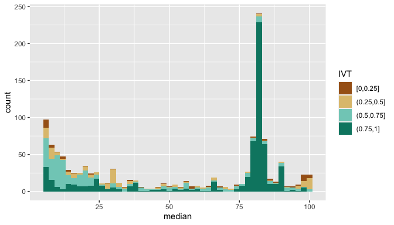

```r
p <- tango.res.df1 %>%
  filter(!in.domain) %>%
  mutate(IVT = cut(ivt, breaks = c(0,0.25,0.5,0.75,1), include.lowest = TRUE),
         Length = cut(length, breaks = c(5,7,9,11,25), include.lowest = TRUE)) %>%
  ggplot(aes(median)) + scale_fill_brewer(type = "div", palette = 1)

p + geom_histogram(aes(fill = IVT), binwidth = 2, position = "stack")
```

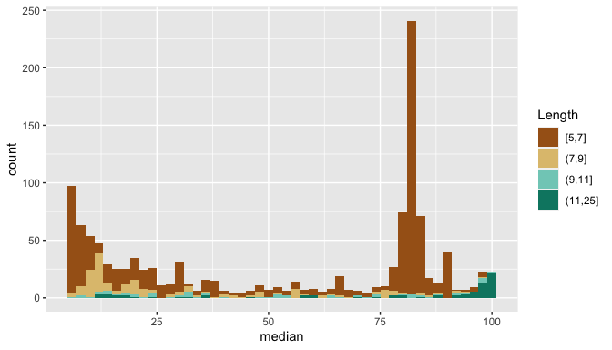

```r
p + geom_histogram(aes(fill = Length), binwidth = 2, position = "stack")
```

**Discussion**

We see that the distribution of scores is somewhat bimodal. If we use 30 as the cutoff, perhaps we will see different types of sequences?

## Cluster motifs by similarity

Many motifs are similar to each other but are listed differently, such as “GVVIVTT” and “GVIVVTT” etc. Our goal is to group them into meaningful clusters and analyze the clusters instead of individual sequences.

There are three steps in the clustering analysis. First, we need to decide on the subset of motif sequences. Based on the score distribution and criterion used by a previous study (from Lipke lab), a median score of 30 is a reasonable cutoff to divide the motifs into two large groups. Second, we need to calculate pairwise distances between the sequences. Intuitively, a distance is a measure of how (dis)similar two sequences are from each other. Proper choice of the distance measure must consider both the mutational processes (substitutions and indels) and amino acid properties, especially in the context of beta-aggregation. Third, we need to decide on the clustering algorithm and, depending on the requirement of the algorithm, we either need to choose the number of clusters beforehand or decide on it afterwards.

### Subset of sequences

Let’s first decide on the set of sequences. I excluded sequences within the PF11765 domain for reasons explained above. Also excluded are TANGO hits at the very N-terminal, which corresponds in most sequences to the signal peptide. Although some of the sequences don’t have a predicted N-terminal signal peptide, since there are only ~10 amino acid in that region, I don’t think it will make a big difference.

With the remaining sequences, I plan to test clustering on all the remaining TANGO hits vs the subset with median score > 30. Based on the distribution shown above, 30 appear to divide the hits into two peaks. A paper from the Lipke lab also used 30 as a cutoff, although it is not clear what summary statistics they used for it.

```r
# get the unique motif sets
seqs <- list(all = unique(tango.res.df1 %>% filter(!in.domain) %>% pull(seq)),
             high = unique(tango.res.df1 %>% filter(!in.domain, median > 30) %>% pull(seq)))
```

### Levenshtein edit distance approach

I’ll be using the `stringdist` package. Here we merely calculate the “edit distance” between sequences, not accounting for amino acid property similarities. Also, sequences of different length would be penalized because insertions are required at the ends of the longer sequence.

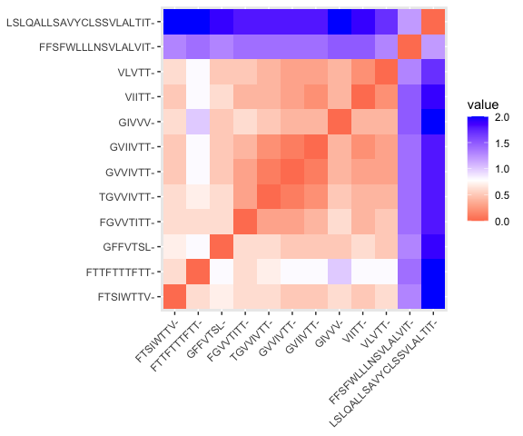

```r
# toy dataset
toy.seqs <- c("GVVIVTT", "GVIIVTT", "GIVVV", "VIITT", "VLVTT", "TGVVIVTT",  "GFFVTSL",
              "FGVVTITT", "FTSIWTTV", "FTTFTTTFTT", "FFSFWLLLNSVLALVIT",
              "LSLQALLSAVYCLSSVLALTIT")
# compute distance matrix between strings using the full Damerau-Levenshtein method
# reference: https://medium.com/my-datascience-journal/using-string-distance-to-group-text-variables-in-r-aa6d0f9226a6
library(stringdist)
toy.dist <- list(edit = stringdistmatrix(toy.seqs, method = "dl", weight = c(d = 0.1, i = 0.1, s = 0.1, t = 1), useNames = TRUE))
fviz_dist(toy.dist$edit)
```

Since “I” and “V” appear to be interchangeable in beta-aggregation sequences, I decide to try replacing all Is with V.

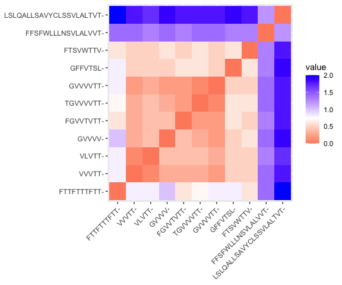

**Discussion**

### Alignment based measure of distance

Here we use the `Biostrings::stringDist()` function to calculate the pairwise distances between the motifs. What’s different about this method compared to the generic string distance function used above is that it is based on pairwise alignment. Specifically, the function uses the following procedure to calculate the distance between any pair of sequences:

1. perform pairwise alignment (local/global) using a given substitution matrix (e.g. BLOSUM62)
2. use the negative of the score as the distance measure

   note that this is different from the edit distance (Levenshtein), which is what is used in the method above

Because the distance calculation is based on pairwise alignment, we need to decide on the “type” of alignment and the scoring matrix to use. According to the [manual](https://bioconductor.org/packages/release/bioc/vignettes/Biostrings/inst/doc/PairwiseAlignments.pdf) of `Biostrings`, there are five types, which differ in which part of the sequence the substitution scoring and gap panelties are applied to:

1. Global

   end-to-end: $[a_1, b_1] = [1,n_1]$ and $[a_2,b_2] = [1,n_2]$, where $n_1$ and $n_2$ denote the lengths of the query and subject sequences, and $a_i$ and $b_i$ denote the starting and end position in the query and subject that the alignment scoring is applied to.
2. Local

   align string fragments: $[a_1, b_1]$ and $[a_2, b_2]$; based on [wikipedia](https://en.wikipedia.org/wiki/Smith%E2%80%93Waterman_algorithm), the local alignment differs from the global alignment in that it sets the negative scoring matrix cells to zero. This means in this mode mismatches are *not penalized*.
3. Overlap

   align whole strings without **end gap** penalties: ${[a_1, b_1] = [a_1,n_1], [a_2, b_2] = [1, b_2]}$ or ${[a_1, b_1] = [1,b_1], [a_2, b_2] = [a_2, n_2]}$
4. Subject overlap (global-local)

   align whole strings in `pattern` with consecutive subsequences of `subject`: $[a_1,b_1]=[1,n_1]$ and $[a_2,b_2]$
5. Query overlap (local-global)

   align consecutive subsequences in `pattern` with whole strings of subject: $[a_1,b_1]$ and $[a_2,b_2]=[1,n_2]$

Lastly, the default for gap opening and extension penalty are 10 and 4, which are quite high for the length of the motif sequences. Therefore we should see no gapped alignment, which I think is the right choice.

```r
mat <- "BLOSUM50"
pa1 <- pairwiseAlignment(toy.seqs, "GVVIVTT", type = "global", substitutionMatrix = mat)
pa2 <- pairwiseAlignment(toy.seqs, "GVVIVTT", type = "local", substitutionMatrix = mat)
pa3 <- pairwiseAlignment(toy.seqs, "GVVIVTT", type = "overlap", substitutionMatrix = mat)
data.frame(pattern = toy.seqs,
           gb.aln = aligned(pa1), gb.d = nedit(pa1), gb.S = score(pa1),
           lc.aln = aligned(pa2), lc.d = nedit(pa2), lc.S = score(pa2),
           ov.aln = aligned(pa3), ov.d = nedit(pa3), ov.S = score(pa3))
```

| pattern | gb.aln | gb.d | gb.S | lc.aln | lc.d | lc.S | ov.aln | ov.d | ov.S |
| --- | --- | --- | --- | --- | --- | --- | --- | --- | --- |
| GVVIVTT | GVVIVTT | 0 | 38 | GVVIVTT | 0 | 38 | GVVIVTT | 0 | 38 |
| GVIIVTT | GVIIVTT | 1 | 37 | GVIIVTT | 1 | 37 | GVIIVTT | 1 | 37 |
| GIVVV | GIVVV-- | 2 | 8 | GIVVV-- | 2 | 26 | GIVVV-- | 2 | 26 |
| VIITT | --VIITT | 1 | 6 | --VIITT | 1 | 24 | --VIITT | 1 | 24 |
| VLVTT | --VLVTT | 1 | 4 | --VLVTT | 1 | 22 | --VLVTT | 1 | 22 |
| TGVVIVTT | GVVIVTT | 0 | 24 | GVVIVTT | 0 | 38 | GVVIVTT | 0 | 38 |
| GFFVTSL | GFFVTSL | 6 | 11 | GFFVTS- | 5 | 12 | GFFVTSL | 6 | 11 |
| FGVVTITT | GVVTITT | 2 | 17 | GVVTITT | 2 | 31 | GVVTITT | 2 | 31 |
| FTSIWTTV | FTSIWTT | 4 | -8 | ---IWTT | 1 | 12 | FTSIWTT | 4 | 6 |
| FTTFTTTFTT | FTTFTTT | 5 | -16 | -TTFTTT | 4 | 10 | ----FTT | 1 | 9 |

[output cut: 2 more lines]

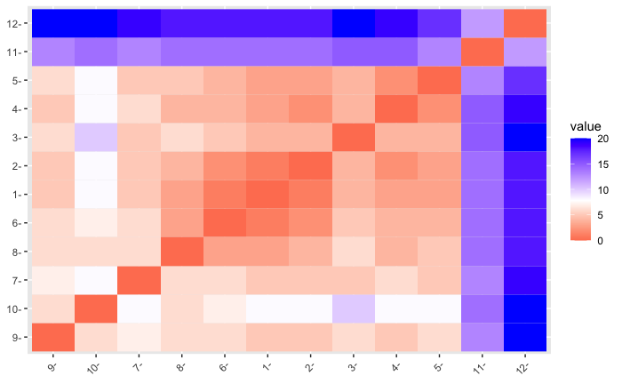

```r
test_stringDist <- function(method = "substitutionMatrix", type = "global", matrix = "BLOSUM50"){
  tmp.dist <- stringDist(toy.seqs, method = method, type = type, substitutionMatrix = matrix, gapOpening = 10, gapExtension = 4)
  tmp <- as.matrix(tmp.dist); rownames(tmp) <- toy.seqs
  fviz_dist(tmp.dist)
}
test_stringDist(method = "levenshtein")
```

Based on the result above, I decide to try “overlap” (which requires at least one end be anchored) with “BLOSUM” substitution matrix to calculate the distance

### clustering

```r
# test the performance of different hierarchical clustering method
# reference: https://uc-r.github.io/hc_clustering
library(cluster)
# methods to assess
m <- c( "average", "single", "complete", "weighted", "ward")
names(m) <- c( "average", "single", "complete", "weighted", "ward")

# function to compute coefficient
ac <- function(x) {
  agnes(motif.dist, method = x)$ac
}

map_dbl(m, ac)
```

[output not shown]

```r
motif.clust <- agnes(motif.dist, method = "ward")
pltree(motif.clust, cex = 0.07, hang = -1)
rect.hclust(as.hclust(motif.clust), h = 4, border = 1:10)
abline(h = 4, lty = 2)
dev.print(pdf, "img/20200727-motif-cluster-dendrogram.pdf")
```

[output not shown]

**Discussion**

```r
h <- seq(from = 3, to = 5, by = 0.5)
seq_grp <- lapply(h, function(x) cutree(as.hclust(motif.clust), h = x))
names(seq_grp) <- paste0("h", h)
cluster_bars <- do.call(cbind, seq_grp);
pltree(motif.clust, cex = 0.05, hang = -1, xlab = "Tango sequences")
dendextend::colored_bars(cluster_bars, as.dendrogram(motif.clust), add = TRUE, y_shift = -3, cex.rowLabels = 0.8)
#abline(h = h, lty = 3)
dev.print(pdf, "img/20200825-tango-word-hierarchical-clustering.pdf", width = 12, height = 5)
```

[output not shown]

*Discussion*

```r
motif.summary$seq_grp <- seq_grp$h3
# number of sequences clustered in the first 6 clusters
table(motif.summary$seq_grp)
# sequences belonging to cluster 1
toplist <- c("group 1" = 1, "group 2" = 2, "group 3" = 3)
lapply(toplist, function(x) paste(head(pull(filter(motif.summary, seq_grp == x), seq), n = 50), collapse = "  "))
```

[output not shown]

*Discussion*

### clustering based on alignment

```r
motif.dist2 <- stringDist(seqs, method = "substitutionMatrix", type = "overlap", substitutionMatrix = "BLOSUM50", gapOpening = 10, gapExtension = 4)
```

```r
asw <- numeric(20)
## Note that "k=1" won't work!
for (k in 2:20)
  asw[k] <- pam(motif.dist2, k, diss = TRUE) $ silinfo $ avg.width
k.best <- which.max(asw)
cat("silhouette-optimal number of clusters:", k.best, "\n")

plot(1:20, asw, type= "b", pch = 19, frame = FALSE, main = "pam() clustering assessment",
     xlab= "k  (# clusters)", ylab = "average silhouette width")
axis(1, k.best, paste("best",k.best,sep="\n"), col = "red", col.axis = "red")
```

[output not shown]

```r
motif.clust2 <- agnes(-motif.dist2, method = "ward")
pltree(motif.clust2, cex = 0.05, hang = -1)
```

[output not shown]

```r
motif.summary$seq_grp <- seq_grp$h3
# number of sequences clustered in the first 6 clusters
table(motif.summary$seq_grp)
# sequences belonging to cluster 1
toplist <- c("group 1" = 1, "group 2" = 2, "group 3" = 3, "group 4" = 4, "group 5" = 5)
lapply(toplist, function(x) paste(head(pull(filter(motif.summary, seq_grp == x), seq), n = 50), collapse = "  "))
```

[output not shown]

### K-medoids clustering, aka partition around medoids (PAM)

Let’s try a different clustering approach, K-medoids, or Partition Around Medoids algorithm For methods, refer to [wikipedia](https://en.wikipedia.org/wiki/K-medoids) and [r doc for the `pam()` function](https://www.rdocumentation.org/packages/cluster/versions/2.1.0/topics/pam). According to the latter, PAM has several advantages over K-means, including clustering around one of the objects (by miniziming within cluster dissimilarity *around* that medoid). This has a great advantage for this case as I can easily examine the “meoids” after the clustering and see if those representatives should have been grouped together.

```r
# construct dissimilarity matrix
# we will use the distance matrix constructed above, i.e. motif.dist
# the following code is adapted from
# https://www.rdocumentation.org/packages/cluster/versions/2.1.0/topics/pam.object
## Use the silhouette widths for assessing the best number of clusters,
## following a one-dimensional example from Christian Hennig :
##
asw <- numeric(25)
## Note that "k=1" won't work!
for (k in 2:25)
  asw[k] <- pam(motif.dist, k, diss = TRUE) $ silinfo $ avg.width
k.best <- which.max(asw)
cat("silhouette-optimal number of clusters:", k.best, "\n")

plot(1:25, asw, type= "b", pch = 19, frame = FALSE, main = "pam() clustering assessment",
     xlab= "k  (# clusters)", ylab = "average silhouette width")
axis(1, k.best, paste("best",k.best,sep="\n"), col = "red", col.axis = "red")
```

[output not shown]

```r
motif.pam <- pam(motif.dist, k = 10, diss = TRUE)
```

### Excluding motifs in the first 300 amino acids

```r
# remake the motif.summary table with those motifs in the N300 a.a. removed
motif.summary1 <- tango.res.df %>%
    filter(start > 300) %>%
    group_by(seq) %>%
    summarize(n = n(), n.protein = n_distinct(id), n.species = n_distinct(species),
              avg.q90 = round(mean(q90),1), sd.q90 = round(sd(q90),2),
              avg.intv = round(mean(interval, na.rm = T),1), sd.intv = round(sd(interval, na.rm = T),2),
              pc.N300 = sum(start <= 300)/n()*100,
              species = paste0(unique(species), collapse = ","), .groups = "drop") %>%
    arrange(desc(n))
# get the unique motif sets
seqs1 <- motif.summary1$seq
# compute distance matrix between strings using the full Damerau-Levenshtein method
# reference: https://medium.com/my-datascience-journal/using-string-distance-to-group-text-variables-in-r-aa6d0f9226a6
motif.dist1 <- stringdistmatrix(seqs1, method = "dl", useNames = TRUE,
                                weight = c(d = 0.12, i = 0.12, s = 0.1, t = 1))
motif.clust1 <- agnes(motif.dist1, method = "ward")
pltree(motif.clust1, cex = 0.05, hang = -1)
dev.print(pdf, "img/20200727-motif-cluster-dendrogram-mN300.pdf")
```

[output not shown]

```r
motif.summary1$seq_grp <- cutree(as.hclust(motif.clust1), h = 2)
# number of sequences clustered in the first 6 clusters
head(table(motif.summary1$seq_grp))

# sequences belonging to cluster 1
toplist <- c("group 1" = 1, "group 2" = 2, "group 3" = 3)
lapply(toplist, function(x) paste(pull(filter(motif.summary1, seq_grp == x), seq), collapse = "  "))

# motif usage in each species
tango.res.df %>%
    filter(start > 300) %>%
    left_join(select(motif.summary, seq, seq_grp), by = c("seq" = "seq")) %>%
    group_by(species) %>%
    summarize(motif.use = paste(sort(unique(seq_grp)), collapse = ","))
```

[output not shown]